# Assignment 2

Tarun Sudhams

11/12/2018

# Question 1 (Chapter 6, Exercise 8 (Page 262))

*In this exercise, we will generate simulated data, and will then use this data to perform best subset selection.*

*(a) Use the rnorm() function to generate a predictor X of length n = 100, as well as a noise vector eps of length n = 100.*

```r
set.seed(1)
x<-rnorm(100)
error<-rnorm(100)
```

*(b) Generate a response vector Y of length n = 100 according to the model Y = β0 + β1X + β2X2 + β3X3 + error, where β0, β1, β2, and β3 are constants of your choice.*

```r
b0 <- 2
b1 <- 3
b2 <- -1
b3 <- 0.5
y <- b0 + b1 * x + b2 * x^2 + b3 * x^3 + error
```

*(c) Use the regsubsets() function to perform best subset selection in order to choose the best model containing the predictors X,X2, . . .,X10. What is the best model obtained according to Cp, BIC, and adjusted R2? Show some plots to provide evidence for your answer, and report the coefficients of the best model obtained.Note you will need to use the data.frame() function to create a single data set containing both X and Y.*

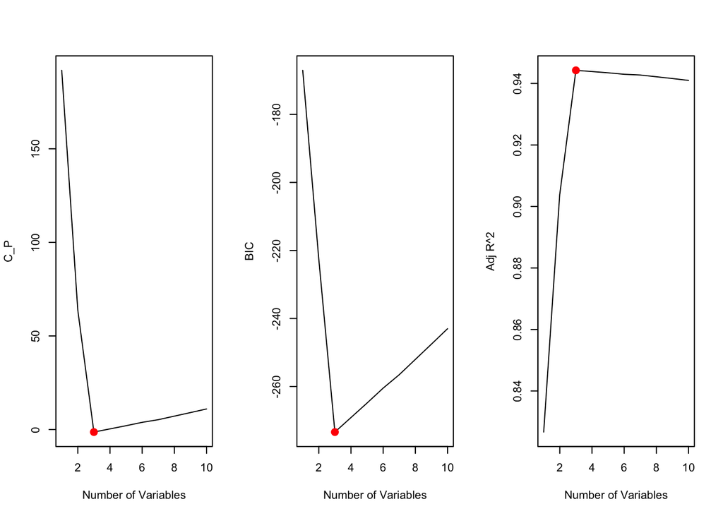

```r
#Following Code Snippet shows the plots to provide evidence for my answer
library(leaps)
data.full<-data.frame(y=y,x=x)
regfit.full<-regsubsets(y~x+I(x^2) + I(x^3) + I(x^4) + I(x^5) + I(x^6) + I(x^7) + I(x^8) + I(x^9) + I(x^10), data = data.full, nvmax = 10, really.big = T)
reg.summary<-summary(regfit.full)
par(mfrow=c(1,3))

#Plotting Model with C_P value
plot(reg.summary$cp,xlab="Number of Variables",ylab="C_P",type="l")
points(which.min(reg.summary$cp),reg.summary$cp[which.min(reg.summary$cp)],col="red",cex=2,pch=20)

#Plotting Model with BIC Value
plot(reg.summary$bic,xlab="Number of Variables",ylab="BIC",type="l")
points(which.min(reg.summary$bic),reg.summary$bic[which.min(reg.summary$bic)],col="red",cex=2,pch=20)

#Plotting Model with adjusted R^2 Value
plot(reg.summary$adjr,xlab="Number of Variables",ylab="Adj R^2",type="l")
points(which.max(reg.summary$adjr),reg.summary$adjr[which.max(reg.summary$adjr)],col="red",cex=2,pch=20)
```

```r
coef(regfit.full,which.max(reg.summary$adjr))
```

```
## (Intercept)           x      I(x^2)      I(x^5)
##  2.07219472  3.44514720 -1.15676236  0.09022577
```

Therefore, the above three plots show that the best subset method gives us a model with 3 predictor variables when C_P, BIC and Adjusted R Square are used as the judgement criteria to select the models The model so obtained selects x, X^2, X^5 as the parameters and hence the original relationship of Y is detailed by x, x^2 and x^5  
*(d) Repeat (c), using forward stepwise selection and also using backwards stepwise selection. How does your answer compare to the results in (c)?.*

First let’s take a look at the Forward Selection Approach

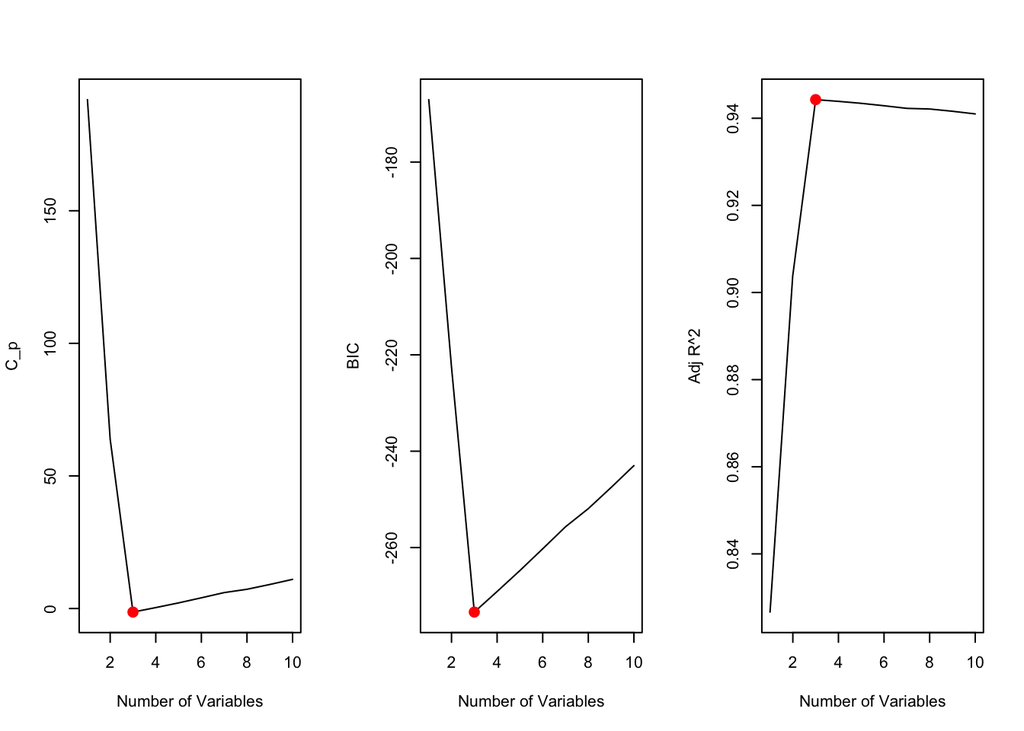

```r
#Forward Selection Approach
data.full<-data.frame(y=y,x=x)
regfit.fwd<-regsubsets(y~x+I(x^2) + I(x^3) + I(x^4) + I(x^5) + I(x^6) + I(x^7) + I(x^8) + I(x^9) + I(x^10), data = data.full, nvmax = 10,really.big = T,method = "forward")
reg.summary.fwd<-summary(regfit.fwd)
par(mfrow=c(1,3))

#Plotting Model with C_P value
plot(reg.summary.fwd$cp,xlab="Number of Variables",ylab="C_p",type="l")
points(which.min(reg.summary.fwd$cp),reg.summary.fwd$cp[which.min(reg.summary.fwd$cp)],col="red",cex=2,pch=20)

#Plotting Model with BIC Value
plot(reg.summary.fwd$bic,xlab="Number of Variables",ylab="BIC",type="l")
points(which.min(reg.summary.fwd$bic),reg.summary.fwd$bic[which.min(reg.summary.fwd$bic)],col="red",cex=2,pch=20)

#Plotting Model with adjusted R^2 Value
plot(reg.summary.fwd$adjr,xlab="Number of Variables",ylab="Adj R^2",type="l")
points(which.max(reg.summary.fwd$adjr),reg.summary.fwd$adjr[which.max(reg.summary.fwd$adjr2)],col="red",cex=2,pch=20)
```

```r
coef(regfit.fwd,which.max(reg.summary.fwd$adjr))
```

```
## (Intercept)           x      I(x^2)      I(x^5)
##  2.07219472  3.44514720 -1.15676236  0.09022577
```

Even with Forward Selection Approach, the model picks x, x^2 and x^5 as predictors

Now, let’s consider the Backward Selection Approach

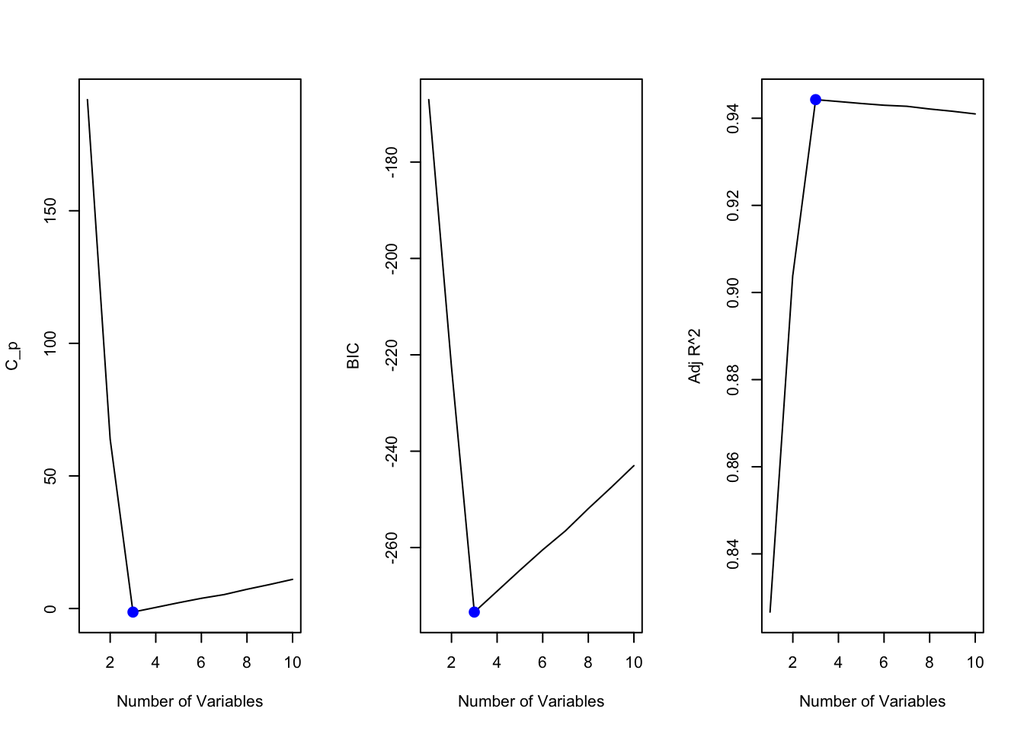

```r
library(leaps)
data.full<-data.frame(y=y,x=x)
regfit.bwd<-regsubsets(y~x+I(x^2) + I(x^3) + I(x^4) + I(x^5) + I(x^6) + I(x^7) + I(x^8) + I(x^9) + I(x^10), data = data.full, nvmax = 10,really.big = T,method = "backward")
reg.summary.bwd<-summary(regfit.bwd)
par(mfrow=c(1,3))

#Plotting Model with C_P value
plot(reg.summary.bwd$cp,xlab="Number of Variables",ylab="C_p",type="l")
points(which.min(reg.summary.bwd$cp),reg.summary.bwd$cp[which.min(reg.summary.bwd$cp)],col="blue",cex=2,pch=20)

#Plotting Model with BIC Value
plot(reg.summary.bwd$bic,xlab="Number of Variables",ylab="BIC",type="l")
points(which.min(reg.summary.bwd$bic),reg.summary.bwd$bic[which.min(reg.summary.bwd$bic)],col="blue",cex=2,pch=20)

#Plotting Model with adjusted R^2 Value
plot(reg.summary.bwd$adjr2,xlab="Number of Variables",ylab="Adj R^2",type="l")
points(which.max(reg.summary.bwd$adjr2),reg.summary.bwd$adjr2[which.max(reg.summary.bwd$adjr2)],col="blue",cex=2,pch=20)
```

The coefficients of the model while using this approach would be:

```r
coef(regfit.bwd,which.max(reg.summary.bwd$adjr2))
```

```
## (Intercept)           x      I(x^2)      I(x^5)
##  2.07219472  3.44514720 -1.15676236  0.09022577
```

Even with the Backward Selection Approach, our model picks x, x^2 and x^5 as the predictors.

*(e) Now ﬁt a lasso model to the simulated data, again using X, X 2 , . . . , X 10 as predictors. Use cross-validation to select the optimal value of λ. Create plots of the cross-validation error as a function of λ. Report the resulting coeﬃcient estimates, and discuss the results obtained.*

```r
library(glmnet)
```

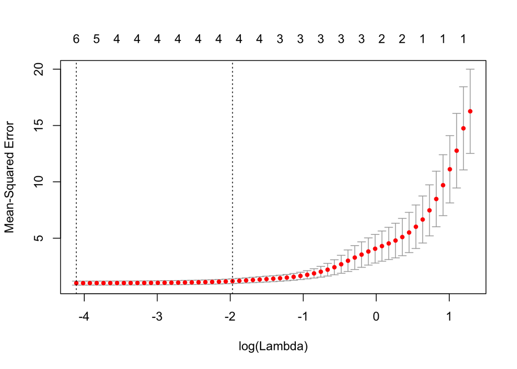

```r
set.seed(1)
xmat<-model.matrix(y ~ x + I(x^2) + I(x^3) + I(x^4) + I(x^5) + I(x^6) + I(x^7) + I(x^8) + I(x^9) + I(x^10), data = data.full)[,-1]
set.seed(1)
cv.lasso<-cv.glmnet(xmat,y,alpha=1)
plot(cv.lasso)
```

```r
lamda_value<-cv.lasso$lambda.min
lamda_value
```

```
## [1] 0.01643032
```

```r
fit.lasso<-glmnet(xmat,y,alpha=1)
predict(fit.lasso,s=lamda_value,type="coefficients")[1:11,]
```

```
##   (Intercept)             x        I(x^2)        I(x^3)        I(x^4)
##  2.067381e+00  3.332843e+00 -1.152061e+00  1.105256e-01  0.000000e+00
##        I(x^5)        I(x^6)        I(x^7)        I(x^8)        I(x^9)
##  6.933641e-02  0.000000e+00  0.000000e+00  1.703182e-06  0.000000e+00
##       I(x^10)
##  4.866746e-05
```

*(f) Now generate a response vector Y according to the model Y=β0+β7X7+error and perform best subset selection and the lasso. Discuss the results obtained.*

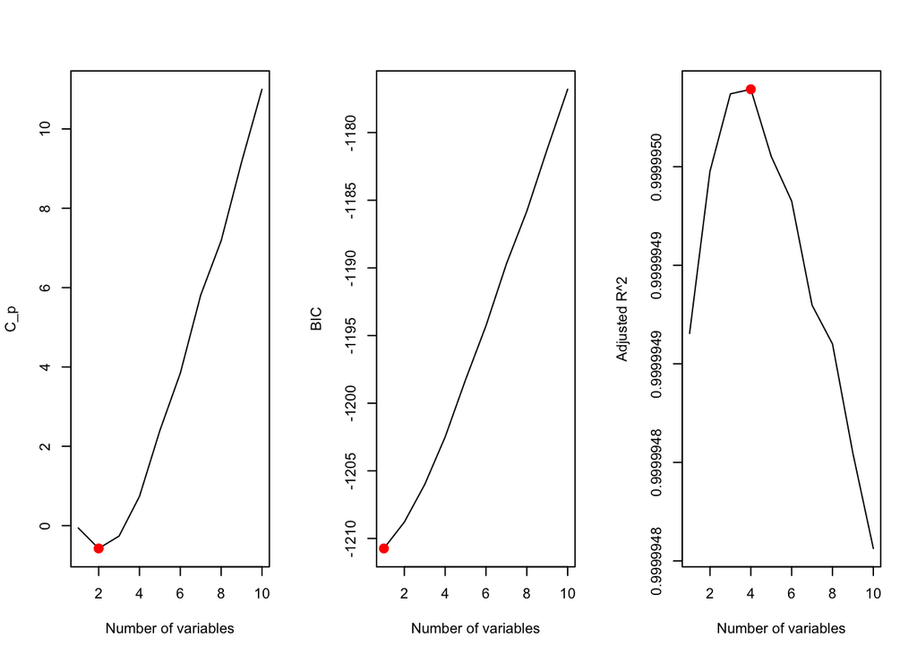

```r
b7<-7
y <- b0 + b7 * x^7 + error
data.full <- data.frame(y = y, x = x)
regfit.full <- regsubsets(y ~ x + I(x^2) + I(x^3) + I(x^4) + I(x^5) + I(x^6) + I(x^7) + I(x^8) + I(x^9) + I(x^10), data = data.full, nvmax = 10)
reg.summary <- summary(regfit.full)
par(mfrow = c(1, 3))
plot(reg.summary$cp, xlab = "Number of variables", ylab = "C_p", type = "l")
points(which.min(reg.summary$cp), reg.summary$cp[which.min(reg.summary$cp)], col = "red", cex = 2, pch = 20)
plot(reg.summary$bic, xlab = "Number of variables", ylab = "BIC", type = "l")
points(which.min(reg.summary$bic), reg.summary$bic[which.min(reg.summary$bic)], col = "red", cex = 2, pch = 20)
plot(reg.summary$adjr2, xlab = "Number of variables", ylab = "Adjusted R^2", type = "l")
points(which.max(reg.summary$adjr2), reg.summary$adjr2[which.max(reg.summary$adjr2)], col = "red", cex = 2, pch = 20)
```

Finding the coefficients for the Best Subset Method

```r
coef(regfit.full,2)
```

```
## (Intercept)      I(x^2)      I(x^7)
##   2.0704904  -0.1417084   7.0015552
```

```r
coef(regfit.full,1)
```

```
## (Intercept)      I(x^7)
##     1.95894     7.00077
```

```r
coef(regfit.full,4)
```

```
## (Intercept)           x      I(x^2)      I(x^3)      I(x^7)
##   2.0762524   0.2914016  -0.1617671  -0.2526527   7.0091338
```

Comparing the values given by Best Subset Method, we can see that Cp chooses a two variable model, while BIC chooses a one variable model and adjusted R square chooses a 4 variables model.

Let’s build a Lasso Model now.

```r
xmat <- model.matrix(y ~ x + I(x^2) + I(x^3) + I(x^4) + I(x^5) + I(x^6) + I(x^7) + I(x^8) + I(x^9) + I(x^10), data = data.full)[, -1]
set.seed(1)
cv.lasso <- cv.glmnet(xmat, y, alpha = 1)
lambda_value <- cv.lasso$lambda.min
lambda_value
```

```
## [1] 13.57478
```

Fitting the Lasso Model

```r
fit.lasso <- glmnet(xmat, y, alpha = 1)
predict(fit.lasso, s = lambda_value, type = "coefficients")[1:11, ]
```

```
## (Intercept)           x      I(x^2)      I(x^3)      I(x^4)      I(x^5)
##    2.904188    0.000000    0.000000    0.000000    0.000000    0.000000
##      I(x^6)      I(x^7)      I(x^8)      I(x^9)     I(x^10)
##    0.000000    6.776797    0.000000    0.000000    0.000000
```

# Question 2(Chapter 8, Exercise 8 (Page 333))

*In the lab, a classiﬁcation tree was applied to the Carseats data set af- ter converting Sales into a qualitative response variable. Now we will seek to predict Sales using regression trees and related approaches, treating the response as a quantitative variable.*

*(a) Split the data set into a training set and a test set.*

```r
library(ISLR)
attach(Carseats)
set.seed(1)
subset<-sample(nrow(Carseats),nrow(Carseats)*0.7)
car.train<-Carseats[subset,]
car.test<-Carseats[-subset,]
```

*(b) Fit a regression tree to the training set. Plot the tree, and inter- pret the results. What test MSE do you obtain?*

```r
library(tree)
car.model.train<-tree(Sales~.,car.train)
summary(car.model.train)
```

```
##
## Regression tree:
## tree(formula = Sales ~ ., data = car.train)
## Variables actually used in tree construction:
## [1] "ShelveLoc"   "Price"       "Age"         "CompPrice"   "Advertising"
## [6] "Population"  "Income"
## Number of terminal nodes:  18
## Residual mean deviance:  2.502 = 655.5 / 262
## Distribution of residuals:
##     Min.  1st Qu.   Median     Mean  3rd Qu.     Max.
## -3.74100 -0.98720 -0.02545  0.00000  1.02000  5.06900
```

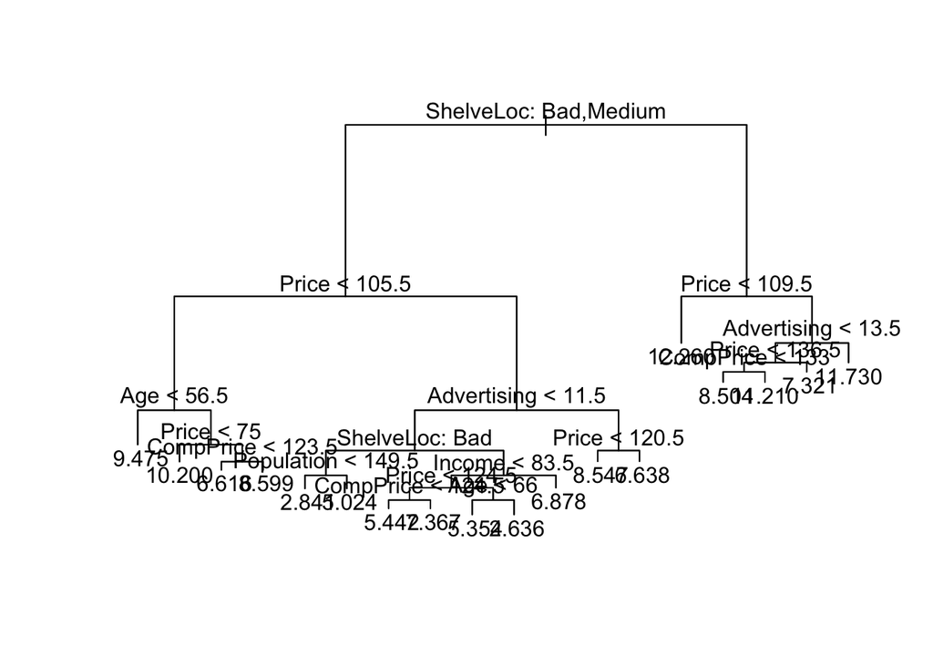

```r
plot(car.model.train)
text(car.model.train,pretty=0)
```

```r
tree.prediction<-predict(car.model.train,newdata=car.test)
tree.mse<-mean((car.test$Sales-tree.prediction)^2)
tree.mse
```

```
## [1] 5.288256
```

The Mean Squared Error of a fully grown tree is 5.288

*(c) Use cross-validation in order to determine the optimal level of tree complexity. Does pruning the tree improve the test MSE?*

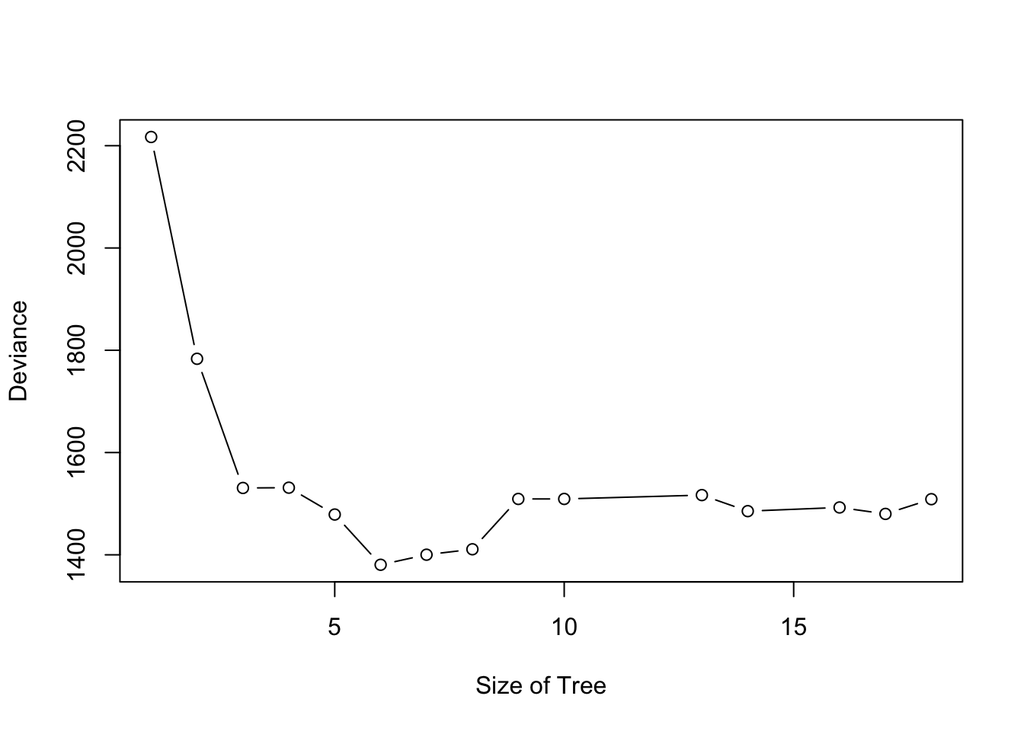

```r
set.seed(1)
cv.car<-cv.tree(car.model.train)
plot(cv.car$size,cv.car$dev,xlab = "Size of Tree",ylab = "Deviance",type = "b")
```

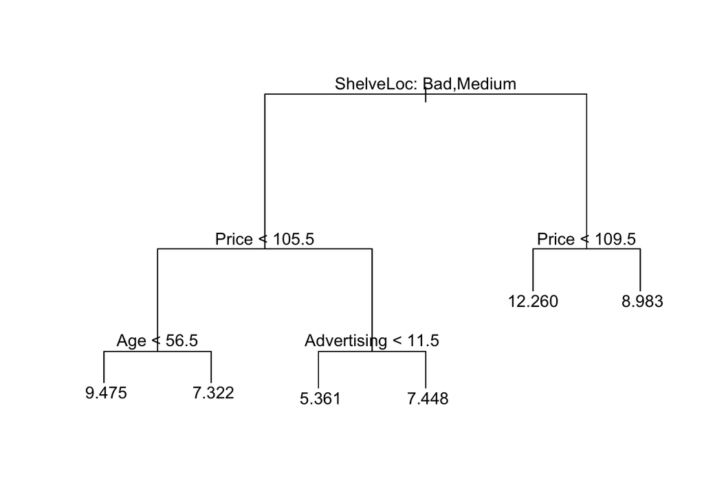

```r
prune.car<-prune.tree(car.model.train,best=6)
plot(prune.car)
text(prune.car,pretty=0)
```

```r
prune.predict<-predict(prune.car,car.test)
mean((prune.predict-car.test$Sales)^2)
```

```
## [1] 5.453816
```

I have used cross validation to find the size to which the tree should be pruned.The size for which the deviance is minimum is selected as the optimal size for pruning

For the pruned tree, I get MSE as 5.454

*(d) Use the bagging approach in order to analyze this data. What test MSE do you obtain? Use the importance() function to determine which variables are most important.*

```r
library(randomForest)
bag.car<-randomForest(Sales~.,car.train,importance=TRUE,mtry=13)
importance(bag.car)
```

```
##                %IncMSE IncNodePurity
## CompPrice   28.1110499    206.844192
## Income       7.1630403    113.560688
## Advertising 21.4156893    183.134088
## Population   4.0903635     97.368359
## Price       66.7161634    694.565053
## ShelveLoc   66.2025804    590.017298
## Age         20.4834974    196.464359
## Education   -0.4322755     52.302750
## Urban       -3.2805229      8.502313
## US           2.4814588      9.939913
```

```r
bag.car.predict<-predict(bag.car,car.test)
mean((bag.car.predict-car.test$Sales)^2)
```

```
## [1] 2.351882
```

We can see that Price & ShelvLoc are the two most important variables chosen by Bagging model.

*(e) Use random forests to analyze this data. What test MSE do you obtain? Use the importance() function to determine which variables aremost important. Describe the effect of m, the number of variables considered at each split, on the error rate obtained.*

```r
rf.car<-randomForest(Sales~.,car.train,importance=TRUE,mtry=sqrt(13))
importance(rf.car)
```

```
##                %IncMSE IncNodePurity
## CompPrice   16.1784429     196.42411
## Income       5.0591257     158.34020
## Advertising 18.3740504     214.11202
## Population   2.3282788     133.18159
## Price       54.1884913     579.19670
## ShelveLoc   49.2616155     498.81054
## Age         14.4678042     214.75275
## Education    0.8583412      76.88235
## Urban       -3.6590144      13.84461
## US           4.8624368      27.94506
```

```r
rf.car.predict<-predict(rf.car,car.test)
mean((rf.car.predict-car.test$Sales)^2)
```

```
## [1] 2.56628
```

Using Random Forest the MSE increased compared to bagging. The important variables chosen by Random Forest are the same as the one chosen by Bagging. Random Forest avoids correlated trees and hence is expected to perform better than Bagging. Here the case is not true.Further tuning of Random Forest model should be tried